# STAT 415 Lab 6: Bayesian Analysis of Rates

TYPE YOUR NAMES HERE

# 1 Introduction

Poisson distributions are often used to model the number of “relatively rare” events that occur over a certain interval of time. In a Poisson distribution situation, the length of the time interval is fixed, e.g., earthquakes in *an hour*, births in *a day*, accidents in *a week*, home runs in *a baseball game*. Given data on time intervals of this fixed length, we measure the *number* of events that happen in each interval

Now we will estimate the *rate* at which events happen by measuring the *time* that elapses between events. *Exponential distributions* are often used to model waiting times between “relatively rare” events that occur over time.

# 2 Instructions

This RMarkdown file provides a template for you to fill in. **Read the file from start to finish, completing the parts as indicated.** **Some code is provided for you. Be sure to run this code, and make sure you understand what it’s doing.** In particular, mind the **PAUSE**s; be sure to **PAUSE** and think about these questions before proceeding.

Some blank “code chunks” are provided; you are welcome to add more (Code > Insert chunk or CTRL-ALT-I) as needed. There are also a few places where you should type text responses. Feel free to add additional text responses as necessary.

You can run individual code chunks using the play button. You can use objects defined in one chunk in others. Just keep in mind that chunks are evaluated in order. So if you call something x in one chunk, but redefine x as something else in another chunk, it’s essential that you evaluate the chunks in the proper order.

- click **Knit** and check to make sure that you have no errors and everything runs properly. (Fix any problems and redo this step until it works.)
- Make sure your type your name(s) at the top of the notebook where it says “Type your name(s) here”. If you worked in a team, you will submit a single notebook with both names; make sure both names are included
- Submit your completed files in Canvas.

You’ll need a few R packages, which you can install using `install.packages`

```r
library(ggplot2)
library(dplyr)
library(knitr)
library(janitor)

knitr::opts_chunk$set(
  echo = TRUE,
  warning = FALSE,
  message = FALSE
)
```

# 3 Exponential distributions

An Exponential distribution is a special case of a Gamma distribution with shape parameter $\alpha=1$. A continuous RV $Y$ has an **Exponential distribution** with *rate parameter*[^1] $\theta>0$ if its density satisfies
$$\begin{align*}
f(y|\theta) & = \theta e^{-\theta y}, \qquad y>0.
\end{align*}$$

In R: `dexp(y, rate)` for density, `rexp` to simulate, `qexp` for quantiles, etc.

The rate parameter $\theta$ will be the parameter of interest in Bayesian analysis of data on waiting times from an Exponential distribution (i.e., Exponential likelihood).

It can be shown that an Exponential($\theta$) density has
$$\begin{align*}
\text{Mean (EV)} & = \frac{1}{\theta}\\
\text{Variance} & = \frac{1}{\theta^2}
\\
\text{Mode} & = 0,\\
\text{Median} & = \frac{\log(2)}{\theta} \approx \frac{0.693}{\theta}
\end{align*}$$

Exponential distributions are often used to model waiting times between events. Data values are measured in units of time, e.g., minutes, hours, etc.

- $\theta$ is the *rate* at which events occur over time (e.g., 2 *per hour* on average)
- $1/\theta$ is the *mean* time between events (e.g., 1/2 *hour* on average)

Exponential distributions have many nice properties, including the following.

**Cumulative waiting time follows a Gamma distribution.** If $Y_1$ and $Y_2$ are independent, $Y_1$ has an Exponential($\theta$) distribution, and $Y_2$ has an Exponential($\theta$) distribution, then $Y_1+Y_2$ has a Gamma distribution[^2] with shape parameter 2 and rate parameter $\theta$. For example, if $Y_1$ represents the waiting time until the first event, and $Y_2$ represents the *additional* waiting time until the second event, then $Y_1+Y_2$ is the total waiting time until 2 events occurs, and $Y_1+Y_2$ follows a Gamma(2, $\theta$) distribution. This result extends naturally to more than two events. If $Y_1, Y_2, \ldots, Y_n$ are independent, each with an Exponential($\theta$) distribution, then $(Y_1+\cdots +Y_n)$ follows a Gamma($n$, $\theta$) distribution. Including the normalizing constant, the Gamma($n$, $\theta$) density is
$$f(y|\theta) = \frac{\theta^n}{(n-1)!}y^{n - 1}e^{-\theta y}, \qquad y>0$$

**Time rescaling.** If $Y$ has an Exponential distribution with rate parameter $\theta$ and $c>0$ is a constant, then $cY$ has an Exponential distribution with rate parameter $\theta/c$. For example, if $Y$ is measured in hours with rate 2 per hour (and mean 1/2 hour), then $60Y$ is measured in minutes with rate 2/60 per minute (and mean 60/2 minutes).

# 4 Earthquake times

Suppose that times (measured in hours, including fractions of an hour) between earthquakes of any magnitude in Southern California follow an Exponential distribution with rate parameter $\theta$. We wish to estimate the rate at which earthquakes occur $\theta$, that is, the average number of earthquakes per hour.

Before proceeding, **PAUSE** to sketch/describe your prior distribution for $\theta$ and describe its features. What are the possible values of $\theta$? Does $\theta$ take values on a discrete or continuous scale?

# 5 Discrete prior

As usual, we’ll start with a discrete prior for $\theta$ to illustrate ideas.

| $\theta$ | 0.25 | 0.50 | 0.75 | 1.00 | 1.25 |
| --- | --- | --- | --- | --- | --- |
| Prior probability | 0.04 | 0.16 | 0.25 | 0.29 | 0.26 |

Suppose a single earthquake with a waiting time of 3.2 hours is observed. Determine the likelihood column of the Bayes table. Find the posterior distribution of $\theta$. For what values of $\theta$ is the posterior probability greater than the prior probability? Why? **PAUSE** to answer these questions before proceeding.

The likelihood is the Exponential($\theta$) density evaluated at $y=3.2$, computed for each value of $\theta$.
$$f(y=3.2|\theta) = \theta e^{-3.2\theta}$$

```r
theta = seq(0.25, 1.25, 0.25)

# prior
prior = c(0.04, 0.16, 0.25, 0.29, 0.26)
prior = prior / sum(prior)

# data
n = 1 # sample size
y = 3.2 # sample mean

# likelihood, using Exponential
likelihood = dexp(y, theta) # function of theta

# posterior
product = likelihood * prior
posterior = product / sum(product)

# bayes table
bayes_table = data.frame(theta,
                         prior,
                         likelihood,
                         product,
                         posterior)

kable(bayes_table, digits = 4, align = 'r')
```

| theta | prior | likelihood | product | posterior |
| --- | --- | --- | --- | --- |
| 0.25 | 0.04 | 0.1123 | 0.0045 | 0.0811 |
| 0.50 | 0.16 | 0.1009 | 0.0162 | 0.2914 |
| 0.75 | 0.25 | 0.0680 | 0.0170 | 0.3069 |
| 1.00 | 0.29 | 0.0408 | 0.0118 | 0.2133 |
| 1.25 | 0.26 | 0.0229 | 0.0060 | 0.1074 |

## 5.1 Exercises

Now suppose a second wait time of 1.6 hours is observed, independently of the first. Find the posterior distribution of $\theta$ after observing these two wait times, using the posterior distribution from the previous part as the prior distribution in this part. For what values of $\theta$ is the posterior probability greater than the prior probability? Why?

```r
# Type your code here.
```

**TYPE YOUR RESPONSE HERE.**

Now consider the original prior again. Suppose that instead of observing the two individual values, we only observe that there is a total of wait time of 4.8 hours for 2 earthquakes. Find the posterior distribution of $\theta$. In particular, how do you determine the likelihood column? How does the likelihood column compare to the one from the previous part? How does posterior compare to the previous part?

```r
# Type your code here.
```

**TYPE YOUR RESPONSE HERE.**

# 6 Grid approximation

Now let’s consider a continuous Gamma(4, 3) prior distribution for $\theta$. **PAUSE** to consider how you can use grid approximation to compute the posterior distribution of $\theta$ given a single wait time of 3.2 hours. (Note: you will need to cut the grid off at some point. While $\theta$ can take any value greater than 0, the interval [0, 5] accounts for 99.98% of the prior probability.)

Create a discrete grid of possible values of $\theta$, say 0, 0.001, 0.002, … For each value of $\theta$ in the grid compute the prior density according to the Gamma(4, 3) distribution
$$\pi(\theta) \propto \theta^{4 -1}e^{-3\theta}, \qquad \theta > 0$$
The likelihood is the Exponential($\theta$) density evaluated at $y=3.2$, computed for each value of $\theta$ in the grid.
$$f(y=3.2|\theta) = \theta e^{-3.2\theta}$$
The likelihood is maximized at the observed sample rate of 1/3.2 = 0.3125 earthquakes per hour.

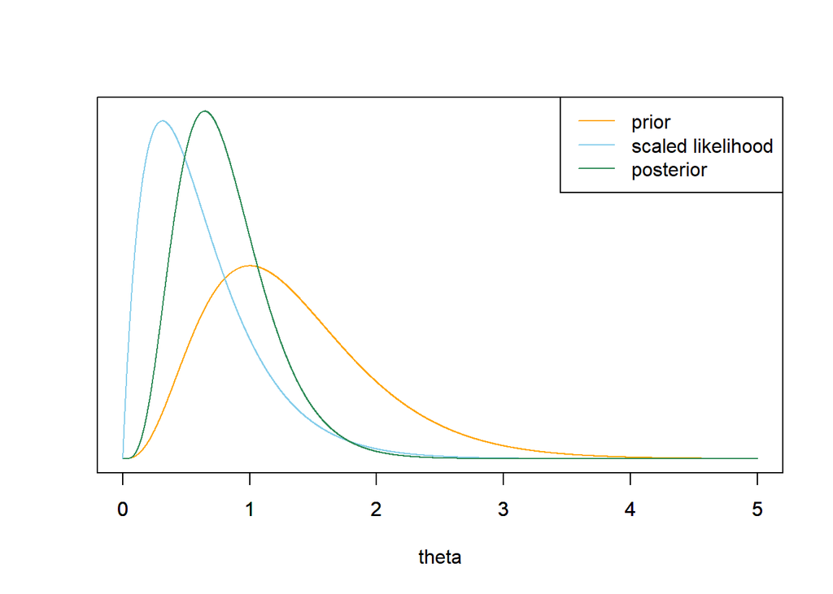

```r
theta = seq(0, 5, 0.001)
# prior

prior = dgamma(theta, shape = 4, rate = 3)
prior = prior / sum(prior)

# data
n = 1 # sample size
y = 3.2 # sample mean

# likelihood
likelihood = dexp(y, theta)

# posterior
product = likelihood * prior
posterior = product / sum(product)

ylim = c(0, max(c(prior, posterior, likelihood / sum(likelihood))))
xlim = range(theta)
plot(theta, prior, type='l', xlim=xlim, ylim=ylim, col="orange", xlab='theta', ylab='', yaxt='n')
par(new=T)
plot(theta, likelihood/sum(likelihood), type='l', xlim=xlim, ylim=ylim, col="skyblue", xlab='', ylab='', yaxt='n')
par(new=T)
plot(theta, posterior, type='l', xlim=xlim, ylim=ylim, col="seagreen", xlab='', ylab='', yaxt='n')
legend("topright", c("prior", "scaled likelihood", "posterior"), lty=1, col=c("orange", "skyblue", "seagreen"))
```

## 6.1 Exercises

Now let’s consider some real data. Assume that waiting times between earthquakes (of any magnitude) in Southern California follow an Exponential distribution with rate $\theta$. Assume a Gamma(4, 3) prior distribution for $\theta$. The following summarizes data for a sample of 100 earthquakes[^3]. There was a total waiting time of 63.09 hours for the 100 earthquakes.

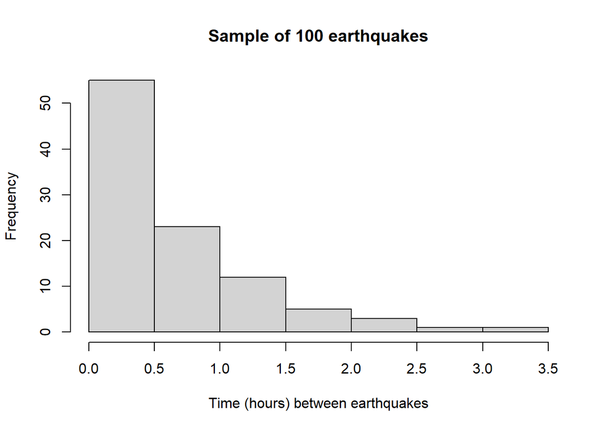

```r
data = read.csv("quakes100.csv")

y = (1 / 60) * data$Waiting.time..minutes.

hist(y, xlab = "Time (hours) between earthquakes",
     main = "Sample of 100 earthquakes")
```

```r
summary(y)
```

```
##      Min.   1st Qu.    Median      Mean   3rd Qu.      Max.
## 0.0008222 0.1263917 0.4572944 0.6308882 0.9394931 3.0761806
```

```r
sd(y)
```

```
## [1] 0.6417422
```

Use grid approximation to compute the posterior distribution of $\theta$ given the data. Be sure to specify the likelihood. Plot the prior, (scaled) likelihood, and posterior. How does posterior compare to the prior?

```r
# Type your code here.
```

**TYPE YOUR RESPONSE HERE.**

# 7 Continuous prior - deriving the posterior

We’ll again assume a continuous Gamma(4, 3) prior distribution for $\theta$. But now we’ll derive the continuous posterior distribution rather than using grid approximation.

**PAUSE** to find the prior mean, prior SD, and a prior 98% credible interval for $\theta$.

The prior mean is $\mu = 4/3$ and the prior SD is $\sigma = \sqrt{4/3^2} = 2/3$. A prior 98% credible interval for $\theta$ is

```r
qgamma(c(0.01, 0.99), shape = 4, rate = 3)
```

```
## [1] 0.2744162 3.3483725
```

**PAUSE** to identify prior density $\pi(\theta)$.

This is just the Gamma(4, 3) density on values of the parameter $\theta$.
$$\pi(\theta) \propto \theta^{4-1}e^{-3\theta}, \qquad \theta > 0.$$

Suppose a single wait time of 3.2 hours is observed. **PAUSE** to write the likelihood function.

The likelihood is the Exponential($\theta$) density evaluated at $y=3.2$, computed for each value of $\theta$.
$$f(y=3.2|\theta) = \theta e^{-3.2\theta}, \qquad \theta > 0$$

**PAUSE** to write an expression for the posterior distribution of $\theta$ given a single wait time of 3.2 hours.

Posterior is proportional to likelihood times prior
$$\begin{align*}
\pi(\theta|y = 3.2) & \propto \left(\theta e^{-3.2\theta}\right)\left(\theta^{4-1}e^{-3\theta}\right), \qquad \theta > 0,\\
& \propto \theta^{(4 + 1) - 1}e^{-(3+3.2)\theta}, \qquad \theta > 0.
\end{align*}$$

**PAUSE** to identify by the name the posterior distribution and the values of relevant parameters.

We recognize the posterior pdf above as the Gamma density with shape parameter $\alpha=4+1$ and rate parameter $\lambda = 3 + 3.2$.

**PAUSE** to find the posterior mean, posterior SD, and a posterior 98% credible interval for $\theta$.

$$\begin{align*}
\text{Posterior mean } & = \frac{\alpha}{\lambda} & & \frac{5}{6.2} = 0.806\\
\text{Posterior SD} & = \sqrt{\frac{\alpha}{\lambda^2}} & & \sqrt{\frac{5}{6.2^2}} = 0.361
\end{align*}$$

```r
qgamma(c(0.01, 0.99), shape = 4 + 1, rate = 3 + 3.2)
```

```
## [1] 0.2063074 1.8717138
```

The following plots the prior distribution, (scaled) likelihood, and posterior distribution. The posterior is similar to what we obtained via grid approximation. Note that we have derived the posterior distribution using theory; the grid below is just for plotting.

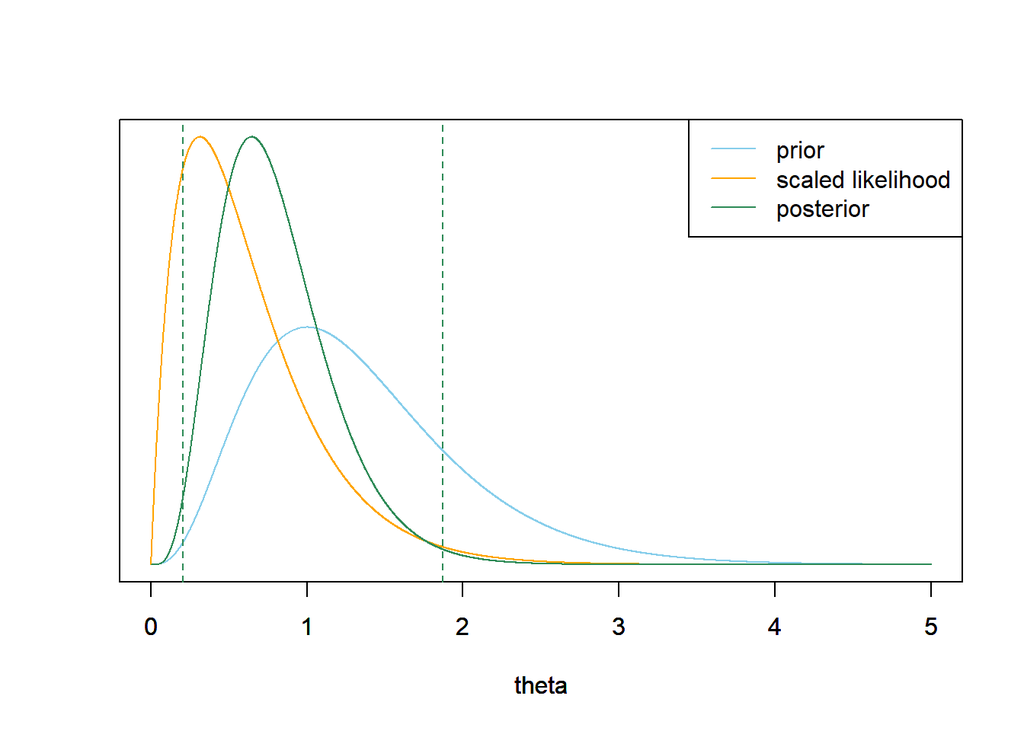

```r
theta = seq(0, 5, 0.001) # the grid is just for plotting

# prior
alpha = 4
lambda = 3
prior = dgamma(theta, shape = alpha, rate = lambda)

# likelihood
n = 1 # sample size
y = 3.2 # sample mean
likelihood = dexp(y, theta)

# posterior
posterior = dgamma(theta, alpha + n, lambda + n * y)

# plot
plot_continuous_posterior <- function(theta, prior, likelihood, posterior) {

  ymax = max(c(prior, posterior))

  scaled_likelihood = likelihood * ymax / max(likelihood)

  plot(theta, prior, type='l', col='skyblue', xlim= range(theta), ylim=c(0, ymax), ylab='', yaxt='n')
  par(new=T)
  plot(theta, scaled_likelihood, type='l', col='orange', xlim=range(theta), ylim=c(0, ymax), ylab='',  yaxt='n')
  par(new=T)
  plot(theta, posterior, type='l', col='seagreen', xlim=range(theta), ylim=c(0, ymax), ylab='', yaxt='n')
  legend("topright", c("prior", "scaled likelihood", "posterior"), lty=1, col=c("skyblue",  "orange", "seagreen"))
}

plot_continuous_posterior(theta, prior, likelihood, posterior)

abline(v = qgamma(c(0.01, 0.99), alpha + n, lambda + n * y),
       col = "seagreen", lty = 2)
```

## 7.1 Exercises

Now consider the original Gamma(4, 3) prior again. Determine the likelihood of observing a wait time of 3.2 hours for the first earthquake and a wait time of 1.6 hours for the second. Find the posterior distribution of $\theta$ given this sample. Identify by the name the posterior distribution and the values of relevant parameters.

```r
# Type your code here.
```

**TYPE YOUR RESPONSE HERE.**

Consider the original prior again. Determine the likelihood of observing a total wait time until two earthquakes of 4.8 hours. Find the posterior distribution of $\theta$ given this sample. Identify by the name the posterior distribution and the values of relevant parameters. How does this compare to the previous part?

```r
# Type your code here.
```

**TYPE YOUR RESPONSE HERE.**

# 8 Gamma-Exponential Model

In the previous example we saw that if the values of the measured variable follow an Exponential distribution with rate parameter $\theta$ and the prior for $\theta$ follows a Gamma distribution, then the posterior distribution for $\theta$ given the data also follows a Gamma distribution.

**Gamma-Exponential model.** Consider a measured variable $Y$ which, given $\theta$, follows an Exponential distribution with rate parameter $\theta$. Let $\bar{y}$ be the sample mean for a random sample of size $n$. Suppose $\theta$ has a Gamma$(\alpha, \lambda)$ prior distribution. Then the posterior distribution of $\theta$ given $\bar{y}$ is the Gamma$(\alpha+n, \lambda+n\bar{y})$ distribution.

That is, Gamma distributions form a *conjugate prior* family for an Exponential likelihood.

The posterior distribution is a compromise between prior and likelihood. For the Gamma-Exponential model, there is an intuitive interpretation of this compromise. In a sense, you can interpret $\alpha$ as “prior number of events” and $\lambda$ as “prior total observation time”, but these are only “pseudo-observations”. Also, $\alpha$ and $\lambda$ are not necessarily integers. (Be careful not confuse this interpretation with the one for Poisson distributions.)

Note that if $\bar{y}$ is the sample mean time between events is then $n\bar{y} = \sum_{i=1}^n y_i$ is the total time of observation.

|  | Prior | Data | Posterior |
| --- | --- | --- | --- |
| Total count | $\alpha$ | $n$ | $\alpha+n$ |
| Total time | $\lambda$ | $n\bar{y}$ | $\lambda + n\bar{y}$ |
| Average rate | $\frac{\alpha}{\lambda}$ | $\frac{1}{\bar{y}}$ | $\frac{\alpha+n}{\lambda+n\bar{y}}$ |

- The posterior “sample size” is the sum of the “prior sample size” $\alpha$ and the observed sample size of $n$.
- The posterior “total time” is the sum of the “prior total observation time” $\lambda$ and the total observation time of $n\bar{y}$.
- The posterior mean is a weighted average of the prior mean of the rate parameter $\theta$ and the sample *rate* ($1/\bar{y}$), with weights proportional to the “total times”.

$$\frac{\alpha+n}{\lambda+n\bar{y}}= \frac{\lambda}{\lambda+n\bar{y}}\left(\frac{\alpha}{\lambda}\right) + \frac{n\bar{y}}{\lambda+n\bar{y}}\left(\frac{1}{\bar{y}}\right)$$

- Larger values of $\lambda$ indicate stronger prior beliefs, due to smaller prior variance, and give more weight to the prior. Roughly, larger $\lambda$ means a “longer prior total observation time”.
- The posterior SD generally gets smaller as more data are collected — via a longer total time of observation $n\bar{y}$. (Since the denominator below is squared, it will be large relative to the numerator).
  $$\text{Posterior SD of $\theta$:} \qquad \sqrt{\frac{\alpha+n}{(\lambda+n\bar{y})^2}}$$

Rather than specifying $\alpha$ and $\beta$, a Gamma distribution prior can be specified by its prior mean and SD directly. If the prior mean is $\mu$ and the prior SD is $\sigma$, then
$$\begin{align*}
\lambda & = \frac{\mu}{\sigma^2}\\
\alpha & = \mu\lambda
\end{align*}$$

## 8.1 Exercises

Consider the data on a sample of 100 earthquakes in the total wait time ws 63.09 hours. Use the theory of the Gamma-Exponential model to find the posterior distribution.

```r
# Type your code here.
```

**TYPE YOUR RESPONSE HERE.**

Plot prior, likelihood, and posterior. Compare to the grid approximation.

```r
# Type your code here.
```

**TYPE YOUR RESPONSE HERE.**

Find the posterior mean, posterior SD, and a posterior 98% credible interval for $\theta$.

```r
# Type your code here.
```

**TYPE YOUR RESPONSE HERE.**

Interpret the credible interval from the previous part in context.

**TYPE YOUR RESPONSE HERE.**

Express the posterior mean of $\theta$ based on the data as a weighted average of the prior mean and the sample mean.

```r
# Type your code here.
```

**TYPE YOUR RESPONSE HERE.**

# 9 Investigating other parameters (Exercises)

The main parameter of an Exponential distribution is the rate parameter, but there are also other related parameters of interest.

**For the rest of the lab, continue to assume the set up of the previous part and the sample of size 100 earthquakes.**

How could you use simulation to find the posterior distribution of the *mean* time between earthquakes. Conduct the simulation and find and interpret a central 98% posterior credible interval for the *mean* time between earthquakes.

```r
# Type your code here.
```

**TYPE YOUR RESPONSE HERE.**

Because the waiting times are skewed to the right, we might be more interested in the *median* time between earthquakes. How could you use simulation to find the posterior distribution of the *median* time between earthquakes. (Hint: use properties of Exponential distributions.) Conduct the simulation and find and interpret a central 98% posterior credible interval for the *median* time between earthquakes.

```r
# Type your code here.
```

**TYPE YOUR RESPONSE HERE.**

# 10 Posterior predictive distribution (Exercises)

Describe in words how you could use simulation (not JAGS) to approximate the posterior predictive distribution of the waiting time until the next earthquake.

**TYPE YOUR RESPONSE HERE.**

Code and run the posterior predictive simulation, plot the results, and find a 95% posterior predictive interval with a lower bound of 0.

```r
# Type your code here.
```

Write a clearly worded sentence interpreting the predictive interval from the previous part.

**TYPE YOUR RESPONSE HERE.**

# 11 JAGS (Exercises)

Use JAGS to approximate the posterior distribution of $\theta$ given the data from the sample of 100 earthquakes. Write the JAGS code, run it, and then summarize the results in appropriate plots and summary values. Compare to the theoretical Gamma distribution from an early part.

```r
# Type your code here.
```

**TYPE YOUR RESPONSE HERE.**

# 12 Optional Exercise - More JAGS

One benefit to using JAGS is that you can use any prior you want. Choose a prior other than Gamma or Uniform for $\theta$ and redo the JAGS code. Is the posterior sensitive to reasonable changes in prior?

```r
# Type your code here.
```

**TYPE YOUR RESPONSE HERE.**

# 13 Reflection

1. Write a few sentences summarizing one important concept you have learned in this lab
2. What is (at least) one question that you still have?

**TYPE YOUR RESPONSE HERE.**

[^1]: Sometimes Exponential densities are parametrized in terms of the *scale parameter* $1/\theta$, so that the mean is $\theta$.
[^2]: This result is a special case of the following. If $Y_1$ and $Y_2$ are independent, $Y_1$ has a Gamma($\alpha_1$, $\theta$) distribution, and $Y_2$ has a Gamma($\alpha_2$, $\theta$) distribution, then $Y_1+Y_2$ has a Gamma distribution with shape parameter $\alpha_1+\alpha_2$ and rate parameter $\theta$. The rate parameters must be the same, for otherwise the variables would be on different scales (e.g., minutes versus hours) and it wouldn’t make sense to add them.
[^3]: Source: Lots of data on earthquakes can be found at https://scedc.caltech.edu/.